### Part II

#### Solution

Tuesday, May 21, 2013

**3.** Consider the following data set:

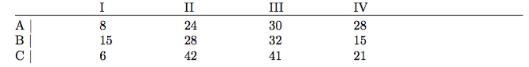

This data set is in MINITAB worksheet `problem3.MTW`. Justify your answers for full credit.

A professor has three sections $(A,B,C)$ of students this quarter. He evaluates all of the student’ written assignments this quarter as “poor” $(I)$, “minimally acceptable” $(II)$, “good” $(III)$, and “excellent” $(IV)$. The number of students who fall in each category in each section is in the table (for example, $32$ students in section $B$ rated “good”).

1. i) If the population of interest is all the students who have or will ever take the class from the professor, what type of sample is this?  
   **Solution**  
   This is a cluster sample (all of the individuals from some groups - whether this is viewed as the sections this quarter or just all the students this quarter - were measured).  
   ii) If the population of interest is all the students taking the class from the professor this quarter, what type of sample is this?  
   **Solution**  
   This is a census (the entire population was measured).

For the rest of this problem, assume that this data set is a random sample from the population of interest.

2. Is there a significant difference between the sections for the ratings at the 5% level?  
   **Solution**  
   $H_0:$ the distributions for the ratings are the same for all 3 sections ($A, B, C$).  
   $H_a:$ the distributions for the ratings different for at least one of the sections.  
   T.S.:

```r
# Easiest way to read data is to manually enter it in
grades.matrix <- matrix(c(8, 24, 30, 28, 15, 28, 32, 15, 6, 42, 41, 21), nrow=3, byrow=TRUE, dimnames=list(c("A", "B", "C"), c("I", "II", "III", "IV")))
grades.matrix
```

```
##    I II III IV
## A  8 24  30 28
## B 15 28  32 15
## C  6 42  41 21
```

```r
# Chi-square test for independence
chisq.test(x=grades.matrix)
```

```
##
##  Pearson's Chi-squared test
##
## data:  grades.matrix
## X-squared = 13.66, df = 6, p-value = 0.03367
```

$\chi^2 = 13.660$ and *p*-value = 0.034. We conclude that at least one of the sections has a different distribution of ratings.

3. Give a 95% confidence interval for the proportion of students who overall rate “excellent.”  
   **Solution**  
   Test of proportions requires that the expected counts exceed 5: $\begin{align*} &\\ n\hat{p} &= 290 \frac{28+15+21}{290} = 64 \\ n(1 - \hat{p}) &= 290 \left(1 - \frac{64}{290} \right) = 226 \end{align*}$ We may proceed.

```r
excellent <- sum(c(28,15,21))
total <- sum(grades.matrix)
prop.test(x=excellent, n=total)
```

```
##
##  1-sample proportions test with continuity correction
##
## data:  excellent out of total, null probability 0.5
## X-squared = 89.383, df = 1, p-value < 2.2e-16
## alternative hypothesis: true p is not equal to 0.5
## 95 percent confidence interval:
##  0.1752130 0.2737306
## sample estimates:
##         p
## 0.2206897
```

4. Give a 95% confidence interval for the proportion of students who overall rate either “good” or “excellent.”  
   **Solution**  
   Test of proportions requires that the expected counts exceed 5: $\begin{align*} &\\ n\hat{p} &= 290 \frac{30+32+41+28+15+21}{290} = 167 \\ n(1 - \hat{p}) &= 290 \left(1 - \frac{167}{290} \right) = 123 \end{align*}$ We may proceed.

```r
good.or.better <- sum(c(30, 32, 41), excellent)
prop.test(x=good.or.better, n=total)
```

```
##
##  1-sample proportions test with continuity correction
##
## data:  good.or.better out of total, null probability 0.5
## X-squared = 6.3759, df = 1, p-value = 0.01157
## alternative hypothesis: true p is not equal to 0.5
## 95 percent confidence interval:
##  0.5166232 0.6330577
## sample estimates:
##         p
## 0.5758621
```

5. Is there sufficient evidence to show that more than half of the students rate either “good” or “excellent”?  
   **Solution**  
   $H_0: p=0.5$  
   $H_a: p>0.5$  
   where $p$ represents the fraction of students in the population who rate either “good” or “excellent.

```r
prop.test(x=good.or.better, n=total, p=0.5, alternative="greater")
```

```
##
##  1-sample proportions test with continuity correction
##
## data:  good.or.better out of total, null probability 0.5
## X-squared = 6.3759, df = 1, p-value = 0.005784
## alternative hypothesis: true p is greater than 0.5
## 95 percent confidence interval:
##  0.5259082 1.0000000
## sample estimates:
##         p
## 0.5758621
```

The *p*-value is 0.005784. We conclude that more than half of the sutdents rate either “good” or “excellent.”